# Data Analysis WVS/EVS Joint Data Set - Imagination Project

Josefina Bernardo

2023-04-25

# Introduction

## The Data

The joint WVS/EVS data set includes data from the World Values Survey and the European Values Study. The joint data set represents the common core of both studies. It covers a wide range of values across 90 different countries, 10 of which are represented in both studies. There are a total of 231 variables which are divided across different thematic categories, such as work, family and the environment.

Here, we specifically look at data from thematic category A: Perceptions of life. In this category, participants were given a list of 11 qualities and had to choose up to five which they considered desirable for a child to have. The qualities were: Good manners, independence, hard work, feeling of responsibility, imagination, tolerance and respect for other people, thrift saving money and things, determination perseverance, religious faith, unselfishness and obedience. We later look at data from category F: Religion and morale, which includes various questions on religious denomination, religious practice and beliefs. Last, we use data from category X: Demographics (Respondent), to assess the participants’ income.

For the second question, we use three external data sets: One on geographical data and two on the gross domestic product per country and per capita.

## Research Questions

We are interested in understanding the role of imagination in different cultures. Specifically, we aim to answer the following questions using the joint data set of the WVS/EVS:

- How important is imagination compared to other qualities/values across countries?
- What are the correlates of valuing imagination?

# Question 1: Importance of Imagination

In the first part, we aim to assess the importance of imagination relative to the other qualities mentioned in the data set (see above) across countries.

## Loading and Extracting Data

We start out by importing the RData File into the environment and loading all packages needed. Since the original data set does not include country names, we add them using the countrycode package. We then do some basic data exploration: Look at the data, calculate summary statistics and identify NAs. We can see there is not a lot of missing data, but some of the ranges are not what we would expect them to be. Many include negative values, which are used to code different types of missing data. We will remove these values and treat them as missing data for each category.

```r
# I supressed the output for this section since its is quite long
# Read in joint EVS/WVS dataset as RData Object
load("~/Downloads/EVS_WVS_Joint_rData_v4_0.rdata")

# Load packages
library(tidyverse)
```

```r
library(countrycode) # Assign county names
library(ggcorrplot) # Correlation matrix
library(rworldmap) # Create maps
library(RColorBrewer) # Color palettes
library(readxl) # Read Excel data sets
library(readr) # Read CSV data

# Adding countries as country names
raw_joint_evs_wvs <- EVS_WVS_Joint_v4_0_Rworkspace %>%
  mutate(cntry_name = countrycode(cntry, origin = "iso3n",
                                  destination = "country.name"),
         continent = countrycode(cntry, origin = "iso3n",
                                  destination = "continent"))

# NIR is not recognized as a country code and produces NAs
raw_joint_evs_wvs$cntry_name <- replace_na(raw_joint_evs_wvs$cntry_name,
                                           "Northern Ireland")

raw_joint_evs_wvs$continent <- replace_na(raw_joint_evs_wvs$continent,
                                           "Europe")

# Data exploration
names(raw_joint_evs_wvs)

raw_joint_evs_wvs %>%
  select(A001:X047E_EVS5) %>%
  summary(.)

dim(raw_joint_evs_wvs)
str(raw_joint_evs_wvs)

head(raw_joint_evs_wvs)

# Looking at missing data
raw_joint_evs_wvs %>%
  is.na() %>%
  colSums() # NA in X002_02A
```

## Category A: Perceptions of Life

We now take a closer look at the data from category A since it contains the imagination variable we are interested in. As a reminder, participants are asked to pick up to 5 qualities which they consider to be important to be taught to children, here. Responses are binary coded: A 1 corresponds to a quality being picked and a 0 corresponds to it not being picked. We perform some basic data cleaning to assure data quality: All rows should sum up to a number between 0 and 5 and the individual values should either be 0 or 1. This step assures that we only include valid data for category A.

```r
# Extracting items of Category A to look at rankings of qualities
catA_data <- raw_joint_evs_wvs %>%
  select(study, wave, year, uniqid, cntry_name, continent, A027:A042) %>%
  rename(good_manners = A027, independence = A029, hard_work = A030,
         responsibility = A032, imagination = A034, tolerance_respect = A035,
         thrift = A038, determination_perseverance = A039,
         religious_faith = A040, unselfishness = A041, obedience = A042) %>%
  mutate(rowsum = rowSums(.[,7:17]))

# Check dimensions and look at data with sums outside of range
head(catA_data)
dim(catA_data)

# Check how many rows need to be removed
catA_data %>%
  select(good_manners:obedience) %>%
  mutate(rowsum = rowSums(.)) %>%
  filter(!(rowsum %in% 0:5))

# Remove row with row sums outside of range
catA_data <- catA_data %>%
  filter(rowsum %in% 0:5) # removes 6823 observations

# Remove rows with individual observations that are not 0 or 1
value_foo <- function(x) all(x %in% c(0,1))
value_mask <- catA_data %>%
  select(good_manners:obedience) %>%
  apply(., MARGIN = 1, FUN = value_foo)


catA_data <- catA_data[value_mask,] # removes another 741 observations
```

### Exploring Data from Category A

We look at the data more closely, calculate correlations and a summary by country. This summary shows the percentage of participants from a given country who have included imagination in the most important values to teach to children.

```r
# Create an overview of sample sizes per country
catA_data %>%
  group_by(cntry_name) %>%
  summarise(n = n()) %>%
  arrange(desc(n))
```

```
## # A tibble: 90 × 2
##    cntry_name         n
##    <chr>          <int>
##  1 Netherlands     4444
##  2 United Kingdom  4358
##  3 Canada          4018
##  4 Russia          3635
##  5 Germany         3544
##  6 Denmark         3323
##  7 Indonesia       3200
##  8 Switzerland     3085
##  9 China           3022
## 10 Romania         2822
## # … with 80 more rows
```

```r
# Do some data exploration on Category A
catA_data %>%
  select(good_manners:obedience) %>%
  summary(.)
```

```
##   good_manners     independence      hard_work      responsibility
##  Min.   :0.0000   Min.   :0.0000   Min.   :0.0000   Min.   :0.0000
##  1st Qu.:1.0000   1st Qu.:0.0000   1st Qu.:0.0000   1st Qu.:0.0000
##  Median :1.0000   Median :0.0000   Median :1.0000   Median :1.0000
##  Mean   :0.7503   Mean   :0.4612   Mean   :0.5052   Mean   :0.6775
##  3rd Qu.:1.0000   3rd Qu.:1.0000   3rd Qu.:1.0000   3rd Qu.:1.0000
##  Max.   :1.0000   Max.   :1.0000   Max.   :1.0000   Max.   :1.0000
##   imagination     tolerance_respect     thrift       determination_perseverance
##  Min.   :0.0000   Min.   :0.000     Min.   :0.0000   Min.   :0.0000
##  1st Qu.:0.0000   1st Qu.:0.000     1st Qu.:0.0000   1st Qu.:0.0000
##  Median :0.0000   Median :1.000     Median :0.0000   Median :0.0000
##  Mean   :0.2069   Mean   :0.654     Mean   :0.3007   Mean   :0.3418
##  3rd Qu.:0.0000   3rd Qu.:1.000     3rd Qu.:1.0000   3rd Qu.:1.0000
##  Max.   :1.0000   Max.   :1.000     Max.   :1.0000   Max.   :1.0000
##  religious_faith unselfishness      obedience
##  Min.   :0.000   Min.   :0.0000   Min.   :0.0000
##  1st Qu.:0.000   1st Qu.:0.0000   1st Qu.:0.0000
##  Median :0.000   Median :0.0000   Median :0.0000
##  Mean   :0.266   Mean   :0.2604   Mean   :0.2516
##  3rd Qu.:1.000   3rd Qu.:1.0000   3rd Qu.:1.0000
##  Max.   :1.000   Max.   :1.0000   Max.   :1.0000
```

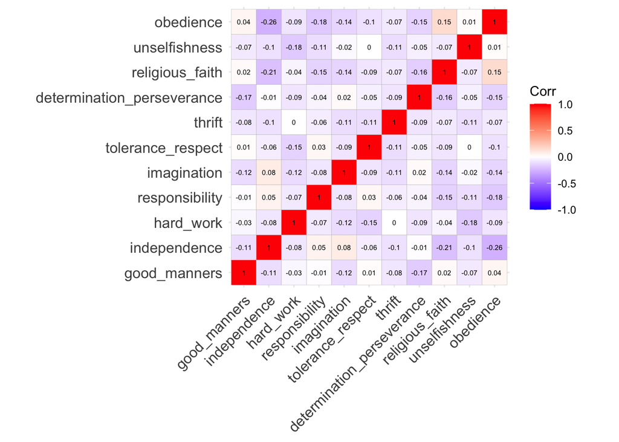

```r
# Create a correlation table - removed for readability
# catA_data %>%
  # select(good_manners:obedience) %>%
  # cor() %>%
  # round(digits = 2)

# Visualize correlation matrix
ggcorrplot(cor(select(catA_data, good_manners:obedience)), lab = TRUE, lab_size = 2)
```

```r
# Calculate average ratings per country
catA_summary <- catA_data %>%
  select(cntry_name, good_manners:obedience) %>%
  group_by(cntry_name) %>%
  summarise(good_manners = mean(good_manners, na.rm = T),
            independence = mean(independence, na.rm = T),
            hard_work = mean(hard_work, na.rm = T),
            responsibility = mean(responsibility, na.rm = T),
            imagination = mean(imagination, na.rm = T),
            tolerance_respect = mean(tolerance_respect, na.rm = T),
            thrift = mean(thrift, na.rm = T),
            determination_perseverance = mean(determination_perseverance, na.rm = T),
            religious_faith = mean(religious_faith, na.rm = T),
            unselfishness = mean(unselfishness, na.rm = T),
            obedience = mean(obedience, na.rm = T))

# Look at overall ranges
catA_summary %>%
  select(good_manners:obedience) %>%
  range()
```

```
## [1] 0.004166667 0.983277592
```

```r
# Look at ranges of imagination
range(catA_summary$imagination)
```

```
## [1] 0.0311284 0.5236948
```

```r
# Check for ties to see whether we need to account for them when ranking
catA_summary %>%
  select(good_manners:obedience) %>%
  rowwise() %>%
  duplicated() %>%
  sum() # No ties
```

```
## [1] 0
```

The correlation table gives us an important insight: Almost all correlations are slightly negative. This makes sense given the structure of the question. If a participant picks any quality, they are automatically less likely to pick one of the other qualities because of the limit of five on number of qualities. The quality variables are, therefore, not independent from each other.

Nonetheless, we can observe some patterns: Picking imagination was positively correlated with picking independence, but negatively with picking obedience and religious faith. Furthermore, picking religious faith and obedience was positively correlated. We should be cautious in interpreting these values since they are likely an underestimation of the true correlations.

### Calculating Ranks for Category A

We calculate a rank of each quality based on the percentages we have obtained during the last step. The percentage tells us how many people have included imagination but it does not show us how important it is compared to other values.

```r
# We calculate ranks per row
ranks_matrix <- catA_summary %>%
  select(good_manners:obedience) %>%
  magrittr::multiply_by(-1) %>%
  apply(1, rank) %>%
  t()

# We combine these ranks with the country names
catA_ranks <- cbind(catA_summary[,1], ranks_matrix)

# Calculate average ranks of imagination per country
range(catA_ranks$imagination)
```

```
## [1]  5 11
```

```r
mean(catA_ranks$imagination)
```

```
## [1] 9.444444
```

```r
median(catA_ranks$imagination)
```

```
## [1] 10
```

## Map Visualizations of Imagination

We can now use the percentages and the ranks to create maps that show us the absolute and relative importance of imagination. We first combine country names, ranks and percentages into one data frame. This allows us to look at the top and bottom countries for imagination percentage and rank (see comments). We then change some country names to make sure the package can plot them. Last, we create a map object and plot the maps.

```r
# Create Maps
imagination_data <- catA_summary %>%
  select(cntry_name, imagination) %>%
  arrange(desc(imagination)) %>%
  left_join(catA_ranks[,c("cntry_name", "imagination")], by = "cntry_name") %>%
  rename(percentage = imagination.x, rank = imagination.y) %>%
  mutate(rank = as.numeric(rank), percentage = as.numeric(percentage * 100))

# Look at top and bottom countries
imagination_data %>% # highest sorted by percentage
  arrange(desc(percentage))
```

```
## # A tibble: 90 × 3
##    cntry_name      percentage  rank
##    <chr>                <dbl> <dbl>
##  1 South Korea           52.4     5
##  2 Norway                43.8     5
##  3 Sweden                41.8     5
##  4 Myanmar (Burma)       41.4     8
##  5 Japan                 40.0     7
##  6 United Kingdom        35.5     8
##  7 Spain                 35.2     7
##  8 Australia             35.0     8
##  9 New Zealand           34.9     8
## 10 Denmark               34.8     6
## # … with 80 more rows
```

```r
imagination_data %>% # highest sorted by rank (and then percentage)
  arrange(rank, desc(percentage))
```

```
## # A tibble: 90 × 3
##    cntry_name    percentage  rank
##    <chr>              <dbl> <dbl>
##  1 South Korea         52.4     5
##  2 Norway              43.8     5
##  3 Sweden              41.8     5
##  4 Tajikistan          33.3     5
##  5 Denmark             34.8     6
##  6 Finland             30.5     6
##  7 Japan               40.0     7
##  8 Spain               35.2     7
##  9 United States       34.0     7
## 10 Switzerland         26.2     7
## # … with 80 more rows
```

```r
imagination_data %>% # Lowest sorted by percentage
  arrange(percentage)
```

```
## # A tibble: 90 × 3
##    cntry_name percentage  rank
##    <chr>           <dbl> <dbl>
##  1 Egypt            3.11    11
##  2 Cyprus           4.4     11
##  3 Georgia          4.86    11
##  4 Zimbabwe         5.02    11
##  5 Indonesia        6.81    11
##  6 Albania          7.94    11
##  7 Libya            8.19    11
##  8 Tunisia          8.37    11
##  9 Maldives         8.90    11
## 10 Malaysia         9.29    11
## # … with 80 more rows
```

```r
imagination_data %>% # Lowest sorted by rank then percentage (identical to the previous one)
  arrange(desc(rank), percentage)
```

```
## # A tibble: 90 × 3
##    cntry_name percentage  rank
##    <chr>           <dbl> <dbl>
##  1 Egypt            3.11    11
##  2 Cyprus           4.4     11
##  3 Georgia          4.86    11
##  4 Zimbabwe         5.02    11
##  5 Indonesia        6.81    11
##  6 Albania          7.94    11
##  7 Libya            8.19    11
##  8 Tunisia          8.37    11
##  9 Maldives         8.90    11
## 10 Malaysia         9.29    11
## # … with 80 more rows
```

```r
# Create Map Object - verbose argument shows some countries failed to match
# imagination_mapdata <- joinCountryData2Map(imagination_data,
                                           # joinCode = "NAME",
                                           # nameJoinColumn = "cntry_name",
                                           # verbose = T)

# We replace some country names to make sure the map function picks up on them
imagination_data <- imagination_data %>%
  mutate(cntry_name = case_when(cntry_name == "Myanmar (Burma)" ~ "Myanmar",
                               cntry_name == "Northern Ireland" ~ "United Kingdom",
                               cntry_name == "Macao SAR China" ~ "Macao",
                               cntry_name == "Bosnia & Herzegovina" ~ "Bosnia and Herzegovina",
                               cntry_name == "North Macedonia" ~ "Macedonia",
                               cntry_name == "Hong Kong SAR China" ~ "Hong Kong",
                               cntry_name == "Czechia" ~ "Czech Republic",
                               TRUE ~ cntry_name))

# Check create object again
imagination_mapdata <- joinCountryData2Map(imagination_data,
                                           joinCode = "NAME",
                                           nameJoinColumn = "cntry_name",
                                           verbose = T)
```

```
## 90 codes from your data successfully matched countries in the map
## 0 codes from your data failed to match with a country code in the map
##      failedCodes failedCountries
## 154 codes from the map weren't represented in your data
```

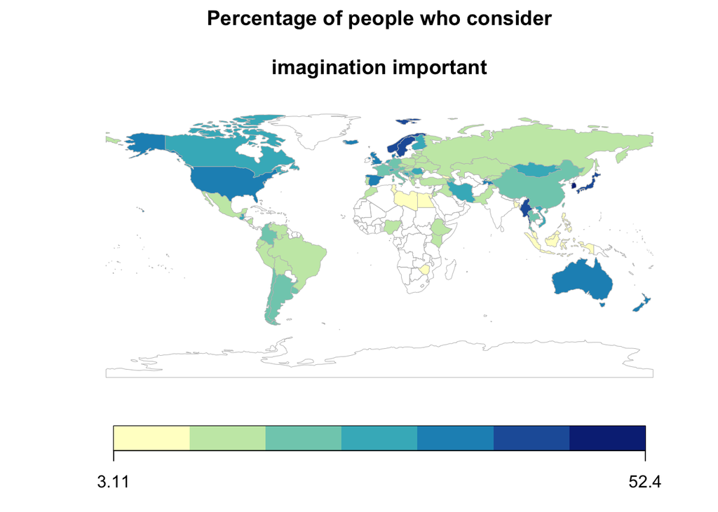

```r
# Map of percentages with title
blue_palette <- brewer.pal(7, "YlGnBu")

mapCountryData(imagination_mapdata, nameColumnToPlot = "percentage",
               mapTitle = "Percentage of people who consider
               \nimagination important",
               colourPalette = blue_palette, catMethod = "fixedWidth")
```

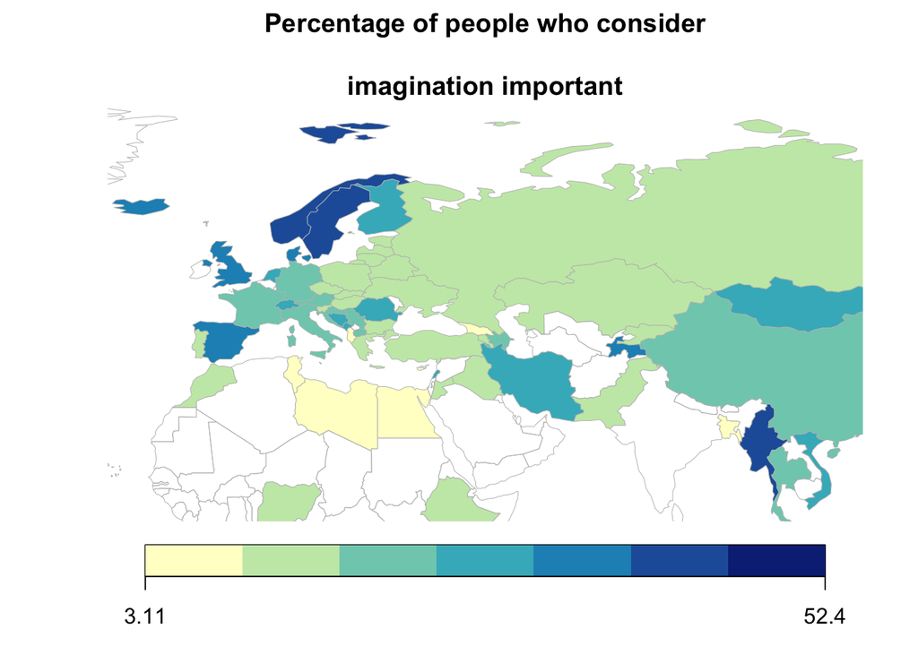

```r
# Map of percentages in Europe
mapCountryData(imagination_mapdata, nameColumnToPlot = "percentage",
               mapRegion = "eurasia",
               mapTitle = "Percentage of people who consider
               \nimagination important",
               colourPalette = blue_palette, catMethod = "fixedWidth")
```

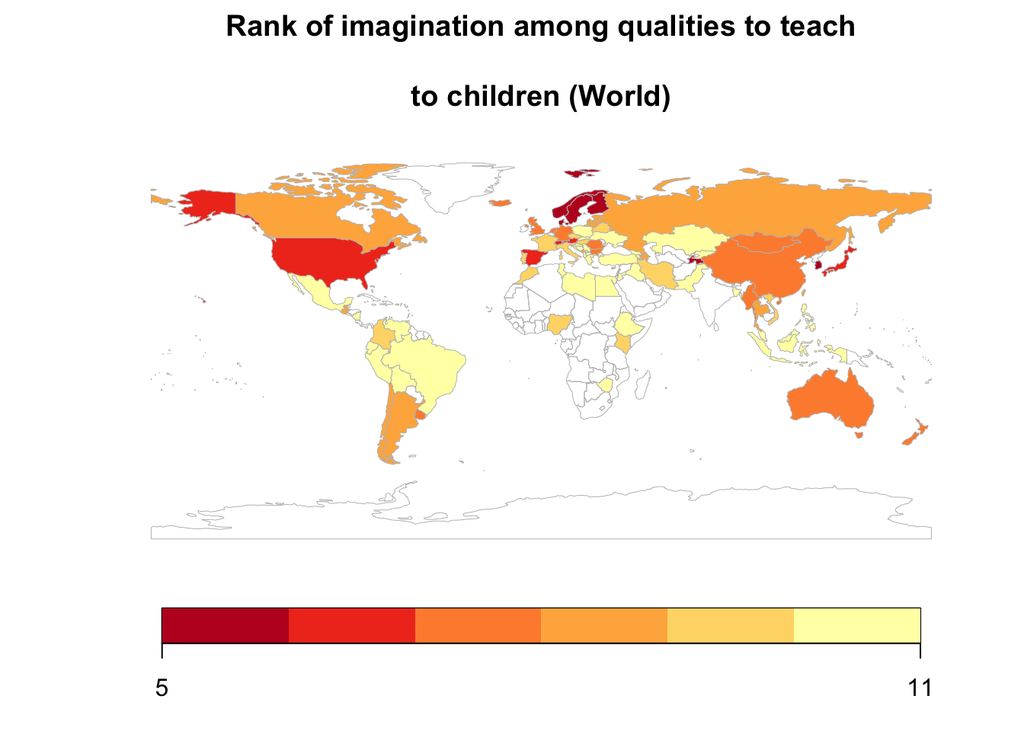

```r
# Map of ranks with title
red_palette <- rev(brewer.pal(6, "YlOrRd"))

mapCountryData(imagination_mapdata, nameColumnToPlot = "rank",
               numCats = 6,
               mapTitle = "Rank of imagination among qualities to teach
               \nto children (World)",
               colourPalette = red_palette, catMethod = "pretty")
```

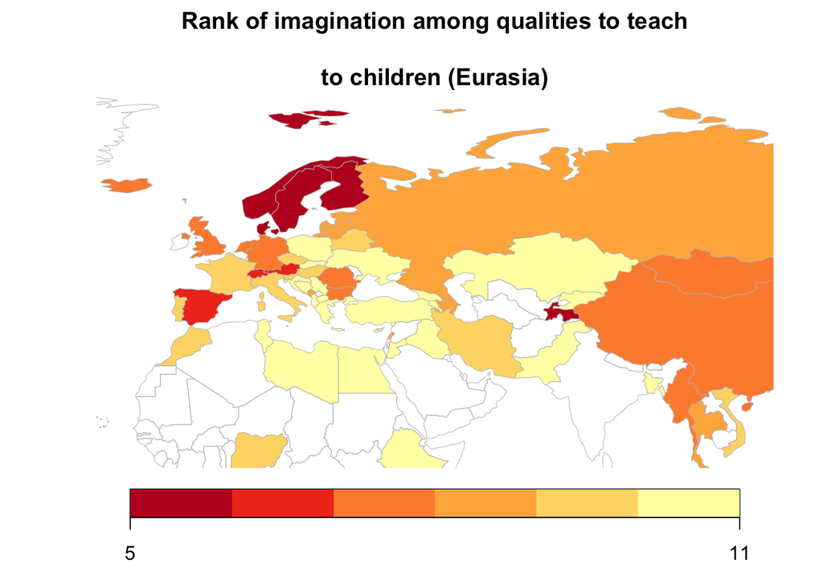

```r
# Map of ranks in Europe
mapCountryData(imagination_mapdata, nameColumnToPlot = "rank",
               mapRegion = "eurasia", numCats = 6,
               mapTitle = "Rank of imagination among qualities to teach
               \nto children (Eurasia)",
               colourPalette = red_palette, catMethod = "pretty")
```

In summary, imagination is among the values that people tend to rate as less important to teach to children. It ranks between 5th and 11th place (out of 11) with between 3.11% and 52.37% of participants for a given country including it in their most important values for a child to have.

We can clearly see that imagination is valued more highly in countries of the global North. Most Scandinavian countries rate imagination more highly in comparison to the rest of Europe.

Based on these analyses we can hypothesize what some other correlates of valuing imagination might be: Perhaps socio-economic status and religiousness could play a role.

# Question 2: Correlates of Imagination

## Other variables within the joint dataset

### Category F: Religion and Morale

For other variables within the dataset, we are particularly interested in variables from the F Category since this includes moral and religious values. The F Category consist of the following items:

- Religious denomination
- How often do you attend religious services?
- Would you say you are a religious person?
- 4 Belief items: Do you believe in… God, life after death, hell, heaven?
- How important in God in your life?
- 13 Justifiability items: Indicate justifiability of… claiming government benefits to which you are not entitled, avoiding public transport fare, cheating on taxes, someone accepting a bribe, homosexuality, prostitution, abortion, divorce, euthanasia, suicide, having casual sex, political violence, death penalty.

First, we perform some data cleaning and rename and recode the variables. All variables are technically categorical, but we treat the justifiability items as continuous since it has a sufficient amount of categories.

```r
# Selecting and renaming columns
F_data <- raw_joint_evs_wvs %>%
  select(uniqid, cntry_name, A034, F025,F028, F034, F050, F051, F053, F054,
         F063, F114A, F115, F116, F117, F118, F119, F120, F121, F122, F123,
         F132, E290, F144_02) %>%
  rename(imagination = A034, religious_denomination = F025,
         attendance_services = F028, religious_person = F034, bel_god = F050,
         bel_afterlife = F051, bel_hell = F053, bel_heaven = F054,
         importance_god = F063, jus_benefits = F114A, jus_fare = F115,
         jus_taxes = F116, jus_bribe = F117, jus_homo = F118, jus_pros = F119,
         jus_abort = F120, jus_divorce = F121, jus_euthanasia = F122,
         jus_suicide = F123, jus_casual = F132, jus_pol_vio = E290,
         jus_death_pen = F144_02)

# Exclude all rows with missing data (153716 to 106814 observations)
F_data <- F_data %>%
  filter(imagination %in% 0:1, religious_denomination %in% 0:9,
         attendance_services %in% c(-3,1:8), religious_person %in% 1:3,
         bel_god %in% 0:1, bel_afterlife %in% 0:1, bel_hell %in% 0:1, bel_heaven %in% 0:1,
         importance_god %in% 1:10, jus_benefits %in% 1:10, jus_fare %in% 1:10,
         jus_taxes %in% 1:10, jus_bribe %in% 1:10, jus_homo %in% 1:10, jus_pros %in% 1:10,
         jus_abort %in% 1:10, jus_divorce %in% 1:10, jus_euthanasia %in% 1:10,
         jus_suicide %in% 1:10, jus_casual %in% 1:10, jus_pol_vio %in% 1:10,
         jus_death_pen %in% 1:10)

# We now recode the variables into factors
bel_cols <- colnames(F_data[,7:10]) # Belief items
jus_cols <- colnames(F_data[,11:24]) # Importance of God + Justifiability items

# Recode variables
#F_data$imagination <- factor(F_data$imagination)
F_data$religious_denomination <- factor(F_data$religious_denomination, levels = 0:9,
                                        labels = c("No denomination", "Roman Catholic",
                                                   "Protestant", "Orthodox", "Jew",
                                                   "Muslim", "Hindu", "Buddhist",
                                                   "Other Christian", "Other"))
F_data$attendance_services <- factor(F_data$attendance_services, levels = c(-3,1:8),
                                     labels = c("Not applicable", "More than once a week",
                                                "Once a week", "Once a month",
                                                "Only on special holy days",
                                                "Other specific holy days", "Once a year",
                                                "Less often", "Never"))
F_data$religious_person <- factor(F_data$religious_person, levels = 1:3,
                                  labels = c("A religious person", "Not a religious person",
                                             "A convinced atheist"))
F_data[bel_cols] <- apply(F_data[,bel_cols], 2, factor)

# We treat the justifiability variables as continuous since they have ten levels
F_data[jus_cols] <- apply(F_data[,jus_cols], 2, as.numeric)
```

Now, we calculate group means per religious denomination to see whether there are any differences. Now we can perform a logistic regression with the imagination variable as an outcome variable.

```r
# Calculating group means
F_data %>%
  group_by(religious_denomination) %>%
  summarise(perc = mean(imagination, na.rm = T))
```

```
## # A tibble: 10 × 2
##    religious_denomination  perc
##    <fct>                  <dbl>
##  1 No denomination        0.304
##  2 Roman Catholic         0.176
##  3 Protestant             0.258
##  4 Orthodox               0.179
##  5 Jew                    0.279
##  6 Muslim                 0.154
##  7 Hindu                  0.144
##  8 Buddhist               0.276
##  9 Other Christian        0.198
## 10 Other                  0.207
```

```r
aov_F <- aov(imagination ~ religious_denomination, data = F_data)
summary(aov_F)
```

```
##                            Df Sum Sq Mean Sq F value Pr(>F)
## religious_denomination      9    391   43.40   252.6 <2e-16 ***
## Residuals              106804  18354    0.17
## ---
## Signif. codes:  0 '***' 0.001 '**' 0.01 '*' 0.05 '.' 0.1 ' ' 1
```

```r
# Fitting a multiple ANOVA
fit_F <- glm(imagination ~ ., data = F_data[,3:24], family = binomial())

summary(fit_F)
```

```
##
## Call:
## glm(formula = imagination ~ ., family = binomial(), data = F_data[,
##     3:24])
##
## Deviance Residuals:
##     Min       1Q   Median       3Q      Max
## -1.3998  -0.7389  -0.5946  -0.4683   2.2986
##
## Coefficients:
##                                                Estimate Std. Error z value
## (Intercept)                                  -1.5489755  0.0495213 -31.279
## religious_denominationRoman Catholic         -0.3667083  0.0262411 -13.975
## religious_denominationProtestant             -0.0541641  0.0274950  -1.970
## religious_denominationOrthodox               -0.1439559  0.0324386  -4.438
## religious_denominationJew                    -0.0782613  0.1451662  -0.539
## religious_denominationMuslim                 -0.2151350  0.0322835  -6.664
## religious_denominationHindu                  -0.5088682  0.1223885  -4.158
## religious_denominationBuddhist                0.3102536  0.0369674   8.393
## religious_denominationOther Christian        -0.1829041  0.0525459  -3.481
## religious_denominationOther                  -0.1377806  0.0536792  -2.567
## attendance_servicesOnce a week               -0.0949244  0.0350768  -2.706
## attendance_servicesOnce a month               0.0718157  0.0372677   1.927
## attendance_servicesOnly on special holy days  0.0325913  0.0346833   0.940
## attendance_servicesOnce a year                0.1020401  0.0418148   2.440
## attendance_servicesLess often                -0.0355932  0.0366250  -0.972
## attendance_servicesNever                      0.0030695  0.0365045   0.084
## religious_personNot a religious person        0.1445567  0.0220265   6.563
## religious_personA convinced atheist           0.3331619  0.0323052  10.313
## bel_god1                                     -0.0048396  0.0275603  -0.176
## bel_afterlife1                                0.1715743  0.0207360   8.274
## bel_hell1                                     0.0844277  0.0262557   3.216
## bel_heaven1                                  -0.1061030  0.0280214  -3.786
## importance_god                               -0.0281732  0.0038822  -7.257
## jus_benefits                                  0.0136867  0.0036233   3.777
## jus_fare                                      0.0259435  0.0036010   7.205
## jus_taxes                                    -0.0067698  0.0047304  -1.431
## jus_bribe                                    -0.0121849  0.0056120  -2.171
## jus_homo                                      0.0428181  0.0032379  13.224
## jus_pros                                      0.0067060  0.0035960   1.865
```

[output cut: 39 more lines]

```
## jus_euthanasia                               0.937823
## jus_suicide                                   < 2e-16 ***
## jus_casual                                    < 2e-16 ***
## jus_pol_vio                                  0.711086
## jus_death_pen                                 < 2e-16 ***
## ---
## Signif. codes:  0 '***' 0.001 '**' 0.01 '*' 0.05 '.' 0.1 ' ' 1
##
## (Dispersion parameter for binomial family taken to be 1)
##
##     Null deviance: 114433  on 106813  degrees of freedom
## Residual deviance: 108958  on 106778  degrees of freedom
## AIC: 109030
##
## Number of Fisher Scoring iterations: 4
```

The ANOVA clearly shows us that the group means of imagination differ significantly between religious denominations. We can get a more detailed understanding from the results of GLM which shows us that belonging to almost any religious denomination significantly lowers the probability of including imagination in comparison to having no religious denomination. The two exceptions are Judaism, which lowers the probability but not significantly so, and Buddhism, which actually increases the probability.

The role of religiousness is further exemplified by whether someone identified as a religious person or not. Someone who said they were ‘not a religious person’ was significantly more likely to include imagination compared to someone who identified as a ‘religious person’. This effect was even stronger for convinced atheists.

### Category X: Demographics - Decile of Income

The data set includes two questions on perceived income. Participants were asked to place themselves in an income decile based on a list of brackets they were given (which were calculated from the average income in their country). A 1 corresponds to the lowest decile and a 10 to the highest

```r
# Internal variable: Perceived income decile
# levels(as.factor(raw_joint_evs_wvs$studytit))

Income_data <- raw_joint_evs_wvs %>%
  select(uniqid, cntry_name, studytit, A034, X047_WVS7, X047E_EVS5) %>%
  rename(imagination = A034, income_wvs7 = X047_WVS7, income_evs5 = X047E_EVS5) %>%
  filter(((studytit == "EVS5" & income_evs5 %in% 1:10) | (studytit == "WVS7" & income_wvs7 %in% 1:10)) &
           imagination %in% 0:1) %>%
  mutate(income = case_when(studytit == "EVS5" ~ income_evs5, studytit == "WVS7" ~ income_wvs7)) %>%
  select(-c(income_evs5, income_wvs7))

# Again, we treat income as a continuous variable
Income_data %>% # Bottom 10 income percentiles
  group_by(cntry_name) %>%
  summarize(mean_percentile = mean(income)) %>%
  arrange(by = mean_percentile)
```

```
## # A tibble: 89 × 2
##    cntry_name mean_percentile
##    <chr>                <dbl>
##  1 Azerbaijan            2.99
##  2 Zimbabwe              3.46
##  3 Georgia               3.48
##  4 Iran                  3.92
##  5 Brazil                4.02
##  6 Jordan                4.04
##  7 China                 4.15
##  8 Albania               4.17
##  9 Japan                 4.19
## 10 Latvia                4.20
## # … with 79 more rows
```

```r
Income_data %>% # Top 10 income percentiles
  group_by(cntry_name) %>%
  summarize(mean_percentile = mean(income)) %>%
  arrange(by = desc(mean_percentile))
```

```
## # A tibble: 89 × 2
##    cntry_name  mean_percentile
##    <chr>                 <dbl>
##  1 Sweden                 6.81
##  2 Croatia                6.24
##  3 Denmark                6.17
##  4 Iceland                6.05
##  5 Finland                6.03
##  6 Guatemala              5.98
##  7 Maldives               5.94
##  8 Netherlands            5.77
##  9 New Zealand            5.69
## 10 Tajikistan             5.64
## # … with 79 more rows
```

```r
# Test income decile as a predictor for imagination
cor.test(Income_data$imagination, Income_data$income)
```

```
##
##  Pearson's product-moment correlation
##
## data:  Income_data$imagination and Income_data$income
## t = 27.293, df = 139999, p-value < 2.2e-16
## alternative hypothesis: true correlation is not equal to 0
## 95 percent confidence interval:
##  0.06753768 0.07795866
## sample estimates:
##        cor
## 0.07275015
```

```r
# Run regression
fit_income <- glm(imagination ~ income, data = Income_data, family = binomial())

summary(fit_income)
```

```
##
## Call:
## glm(formula = imagination ~ income, family = binomial(), data = Income_data)
##
## Deviance Residuals:
##     Min       1Q   Median       3Q      Max
## -0.8280  -0.7268  -0.6798  -0.6137   1.8773
##
## Coefficients:
##              Estimate Std. Error z value Pr(>|z|)
## (Intercept) -1.649373   0.015712 -104.98   <2e-16 ***
## income       0.075511   0.002781   27.15   <2e-16 ***
## ---
## Signif. codes:  0 '***' 0.001 '**' 0.01 '*' 0.05 '.' 0.1 ' ' 1
##
## (Dispersion parameter for binomial family taken to be 1)
##
##     Null deviance: 147317  on 140000  degrees of freedom
## Residual deviance: 146578  on 139999  degrees of freedom
## AIC: 146582
##
## Number of Fisher Scoring iterations: 4
```

We observe a very weak positive correlation between income decile and whether imagination was included. In a logistic regression, income significantly predicted whether imagination was included.

## External data

Now we use some external data sets to find correlates of imagination, namely:

- Data on Global North vs. Global South
- GDP per country
- GDP per capita

### Data on Global North vs. Global South

We use a data set which was manually extracted from Wikipedia to see whether our impression that the global North is more likely to value imagination than the Global South is correct.

```r
# External variable: North South
North_South_Geo_Data <- read_excel("Downloads/North_South_Geo_Data.xlsx")

North_South_Geo_Data <- North_South_Geo_Data %>%
  mutate(Country = case_when(Country == "Bosnia and Herzegovina" ~ "Bosnia & Herzegovina",
                             Country == "Czech Republic" ~ "Czechia",
                             Country == "Hong Kong" ~ "Hong Kong SAR China",
                             Country == "Iran, Islamic Republic of" ~ "Iran",
                             Country == "Macau" ~ "Macao SAR China",
                             Country == "Myanmar" ~ "Myanmar (Burma)",
                             Country == "Macedonia" ~ "North Macedonia",
                             Country == "Russian Federation" ~ "Russia",
                             Country == "Korea, Republic of" ~ "South Korea",
                             TRUE ~ Country))

north_south_data <- catA_data %>%
  mutate(cntry_name = case_when(cntry_name == "Northern Ireland" ~ "United Kingdom",
                                TRUE ~ cntry_name)) %>%
  left_join(North_South_Geo_Data, by = c("cntry_name" = "Country"))

# Check for NAs
# levels(as.factor(north_south_data[is.na(north_south_data$`Global North or Global South?`), "cntry_name"]))

# ANOVA
aov_ns <- aov(imagination ~ `Global North or Global South?`, data = north_south_data)
summary(aov_ns)
```

```
##                                     Df Sum Sq Mean Sq F value Pr(>F)
## `Global North or Global South?`      1    128  127.95   783.9 <2e-16 ***
## Residuals                       146150  23856    0.16
## ---
## Signif. codes:  0 '***' 0.001 '**' 0.01 '*' 0.05 '.' 0.1 ' ' 1
```

```r
fit_ns <- glm(imagination ~ `Global North or Global South?`, data = north_south_data, family = binomial())
summary(fit_ns)
```

```
##
## Call:
## glm(formula = imagination ~ `Global North or Global South?`,
##     family = binomial(), data = north_south_data)
##
## Deviance Residuals:
##     Min       1Q   Median       3Q      Max
## -0.7219  -0.7219  -0.6064  -0.6064   1.8890
##
## Coefficients:
##                                              Estimate Std. Error z value
## (Intercept)                                 -1.211785   0.007811 -155.13
## `Global North or Global South?`Global South -0.388452   0.013962  -27.82
##                                             Pr(>|z|)
## (Intercept)                                   <2e-16 ***
## `Global North or Global South?`Global South   <2e-16 ***
## ---
## Signif. codes:  0 '***' 0.001 '**' 0.01 '*' 0.05 '.' 0.1 ' ' 1
##
## (Dispersion parameter for binomial family taken to be 1)
##
##     Null deviance: 149031  on 146151  degrees of freedom
## Residual deviance: 148233  on 146150  degrees of freedom
## AIC: 148237
##
## Number of Fisher Scoring iterations: 4
```

```r
north_south_data %>%
  group_by(`Global North or Global South?`) %>%
  summarize(north_south_mean = mean(imagination))
```

```
## # A tibble: 2 × 2
##   `Global North or Global South?` north_south_mean
##   <chr>                                      <dbl>
## 1 Global North                               0.229
## 2 Global South                               0.168
```

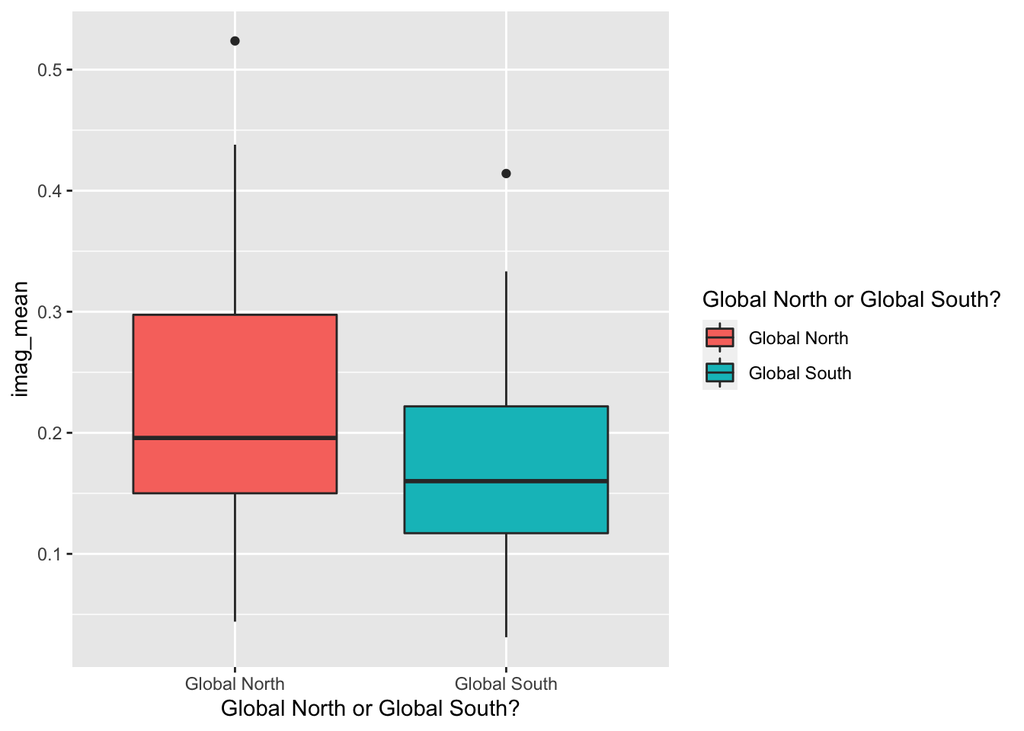

```r
north_south_data %>%
  group_by(cntry_name, `Global North or Global South?`) %>%
  summarize(imag_mean = mean(imagination)) %>%
  ggplot(., aes(x = `Global North or Global South?`, y = imag_mean, fill = `Global North or Global South?`)) +
    geom_boxplot()
```

The ANOVA and fitting GLM confirms our impression that the global South is indeed less likely to value imagination over the other options.

### Gross domestic product by country

We import an external dataset of the GDP of each country and merge it to the data from Category A. By using the GDP, we aim to understand whether differences in socio-economic status between countries might correlate with valuing imagination. We first merge both datasets.

```r
# External variable: Country GDP

# Load in external GDP dataset from https://www.kaggle.com/datasets/alejopaullier/-gdp-by-country-1999-2022
GDP_by_Country <- read_csv("Downloads/GDP by Country 1999-2022.csv")
# Change country names for merging
GDP_by_Country <- GDP_by_Country %>%
  mutate(Country = case_when(Country == "Bosnia and Herzegovina" ~ "Bosnia & Herzegovina",
                                Country == "Czech Republic" ~ "Czechia",
                                Country == "Hong Kong SAR" ~ "Hong Kong SAR China",
                                Country == "Iran, Islamic Republic of" ~ "Iran",
                                Country == "Kyrgyz Republic" ~ "Kyrgyzstan",
                                Country == "Myanmar" ~ "Myanmar (Burma)",
                                Country == "Macedonia, Former Yugoslav Republic of" ~ "North Macedonia",
                                Country == "Slovak Republic" ~ "Slovakia",
                                Country == "Korea" ~ "South Korea",
                                Country == "Taiwan Province of China" ~ "Taiwan",
                                TRUE ~ Country))

# Transform from wide to long format
GDP_by_Country$Country <- factor(GDP_by_Country$Country)
GDP_by_Country <- gather(GDP_by_Country, "Year", "GDP", 2:24)


# Append GDPs to Category A dataset (we have already selected valid data from Category A above)
# levels(as.factor(catA_data$year))
# levels(as.factor(GDP_by_Country$Year))
GDP_by_Country$Year <- as.integer(GDP_by_Country$Year)

gdp_data <- catA_data %>%
  mutate(cntry_name = case_when(cntry_name == "Northern Ireland" ~ "United Kingdom",
                             TRUE ~ cntry_name)) %>%
  left_join(GDP_by_Country, by = c("year" = "Year", "cntry_name" = "Country"))

# levels(as.factor(gdp_data[is.na(gdp_data$GDP), "cntry_name"]))
```

With the merged data set, we can now calculate correlations, run a regression and plot the imagination mean (= percentage of people who have included imagination in their values) against the GDP.

```r
# Calculate correlation
gdp_data %>%
  group_by(cntry_name, year, GDP) %>%
  summarise(imag_mean = mean(imagination)) %>%
  arrange(by = desc(imag_mean))
```

```
## # A tibble: 96 × 4
## # Groups:   cntry_name, year [96]
##    cntry_name       year   GDP imag_mean
##    <chr>           <int> <dbl>     <dbl>
##  1 South Korea      2018 1649.     0.524
##  2 Norway           2018  436.     0.438
##  3 Sweden           2017  520.     0.418
##  4 Myanmar (Burma)  2020  106.     0.414
##  5 Japan            2019 4591.     0.400
##  6 United Kingdom   2022 3442.     0.359
##  7 Spain            2017 1319.     0.352
##  8 Australia        2018 1382.     0.350
##  9 New Zealand      2020  195.     0.349
## 10 Denmark          2017  316.     0.348
## # … with 86 more rows
```

```r
cor.test(gdp_data$imagination, gdp_data$GDP)
```

```
##
##  Pearson's product-moment correlation
##
## data:  gdp_data$imagination and gdp_data$GDP
## t = 24.652, df = 141143, p-value < 2.2e-16
## alternative hypothesis: true correlation is not equal to 0
## 95 percent confidence interval:
##  0.06028058 0.07066973
## sample estimates:
##        cor
## 0.06547693
```

```r
# Run regression
fit_GDP <- glm(imagination ~ GDP, data = gdp_data, family = binomial())

summary(fit_GDP)
```

```
##
## Call:
## glm(formula = imagination ~ GDP, family = binomial(), data = gdp_data)
##
## Deviance Residuals:
##     Min       1Q   Median       3Q      Max
## -0.9390  -0.6705  -0.6631  -0.6619   1.8036
##
## Coefficients:
##               Estimate Std. Error z value Pr(>|z|)
## (Intercept) -1.408e+00  7.145e-03 -197.00   <2e-16 ***
## GDP          4.178e-05  1.727e-06   24.19   <2e-16 ***
## ---
## Signif. codes:  0 '***' 0.001 '**' 0.01 '*' 0.05 '.' 0.1 ' ' 1
##
## (Dispersion parameter for binomial family taken to be 1)
##
##     Null deviance: 143788  on 141144  degrees of freedom
## Residual deviance: 143245  on 141143  degrees of freedom
##   (5007 observations deleted due to missingness)
## AIC: 143249
##
## Number of Fisher Scoring iterations: 4
```

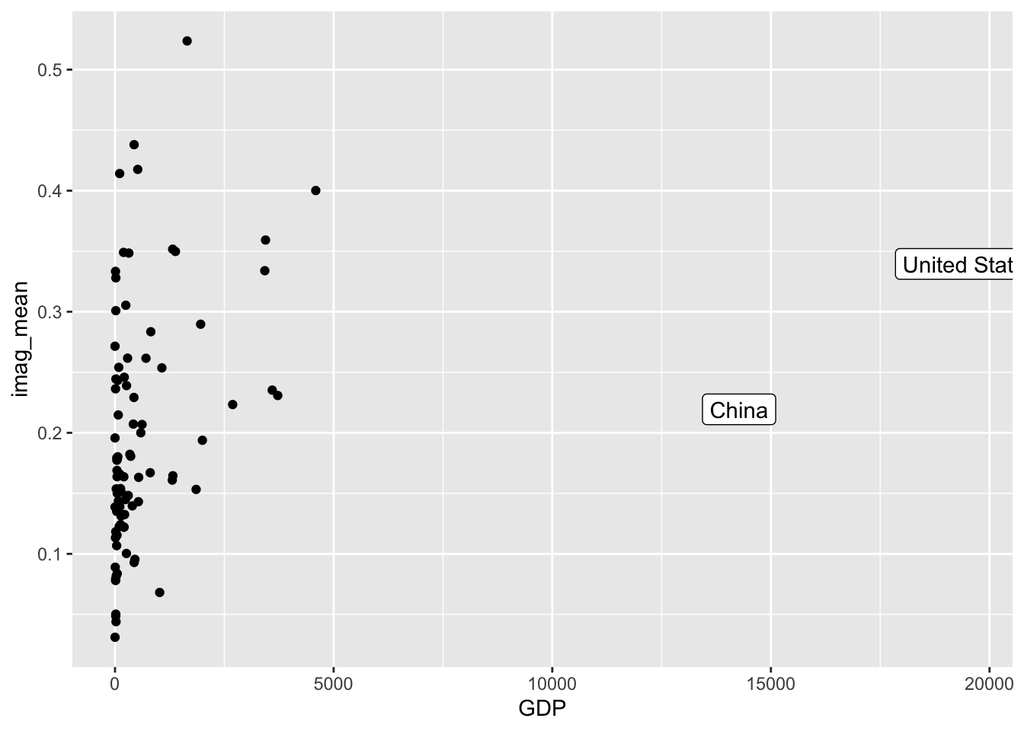

```r
# Join North South Data
gdp_data <- cbind(gdp_data, north_south_data$`Global North or Global South?`)
colnames(gdp_data)[20] <- "north_south_var"

# Visualize these results
gdp_data %>%
  group_by(cntry_name, year, GDP) %>%
  summarise(imag_mean = mean(imagination)) %>%
  ggplot(., aes(x = GDP, y = imag_mean)) +
    geom_point() +
    geom_label(data = . %>% filter(GDP > 5000),
               aes(label = cntry_name))
```

We observe substantial outliers which seem to bias the correlation - the GDPs of China and the US are more than three standard deviations from the mean GDP. Therefore, we exclude GDPs which are above 3 standard deviations from the mean GDP, compute a new correlations coefficient and re-run the regression. We visualize overall results the same as before and split plots by continent to get an impression of differences between continents.

```r
# Remove outliers and NAs
gdp_summary <- gdp_data %>%
  group_by(cntry_name, year, GDP, continent, north_south_var) %>%
  summarise(imag_mean = mean(imagination)) %>%
  arrange(by = desc(GDP))
```

```
## You can override using the `.groups` argument.
```

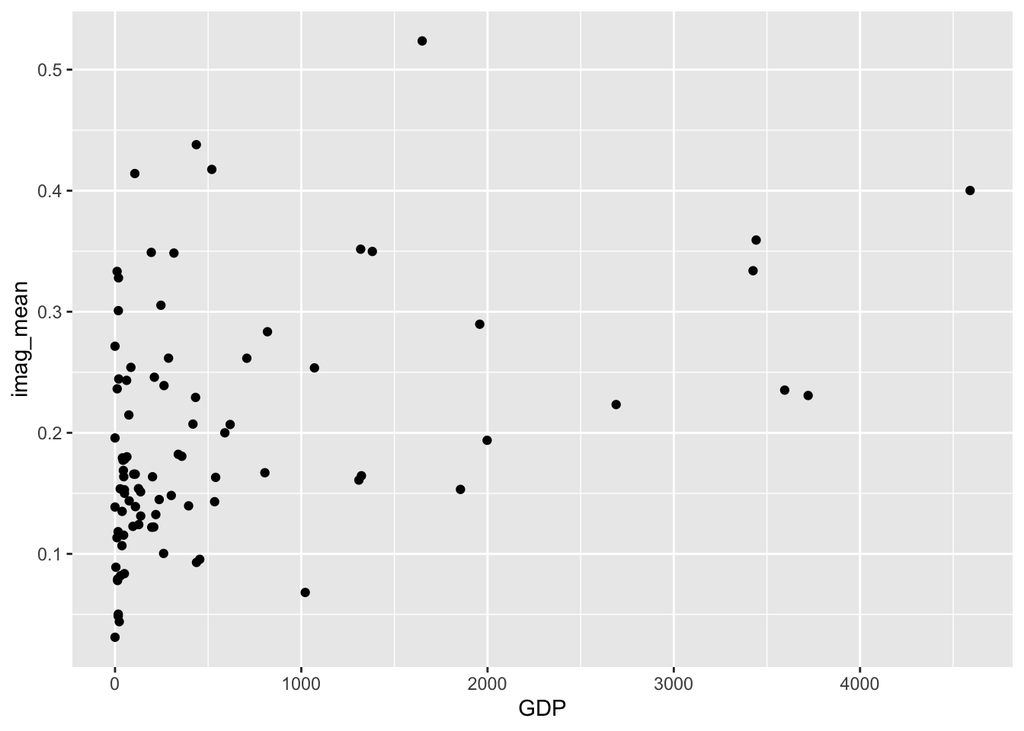

```r
gdp_summary <- gdp_summary %>%
  filter(GDP < mean(gdp_summary$GDP, na.rm = T) + 3*sd(gdp_summary$GDP, na.rm = T) &
           GDP > mean(gdp_summary$GDP, na.rm = T) - 3*sd(gdp_summary$GDP, na.rm = T))

ggplot(gdp_summary, aes(x = GDP, y = imag_mean)) +
  geom_point()
```

```r
# Re-run correlation test and regression without outliers
gdp_data_2 = gdp_data %>%
  filter(cntry_name %in% gdp_summary$cntry_name) %>%
  select(imagination, GDP)

cor.test(gdp_data_2$imagination, gdp_data_2$GDP)
```

```
##
##  Pearson's product-moment correlation
##
## data:  gdp_data_2$imagination and gdp_data_2$GDP
## t = 35.992, df = 135529, p-value < 2.2e-16
## alternative hypothesis: true correlation is not equal to 0
## 95 percent confidence interval:
##  0.09202588 0.10257286
## sample estimates:
##       cor
## 0.0973021
```

```r
fit_GDP_2 <- glm(imagination ~ GDP, data = gdp_data_2, family = binomial())

summary(fit_GDP_2)
```

```
##
## Call:
## glm(formula = imagination ~ GDP, family = binomial(), data = gdp_data_2)
##
## Deviance Residuals:
##     Min       1Q   Median       3Q      Max
## -0.9539  -0.6601  -0.6333  -0.6274   1.8570
##
## Coefficients:
##               Estimate Std. Error z value Pr(>|z|)
## (Intercept) -1.528e+00  8.436e-03  -181.1   <2e-16 ***
## GDP          2.126e-04  6.007e-06    35.4   <2e-16 ***
## ---
## Signif. codes:  0 '***' 0.001 '**' 0.01 '*' 0.05 '.' 0.1 ' ' 1
##
## (Dispersion parameter for binomial family taken to be 1)
##
##     Null deviance: 137031  on 135530  degrees of freedom
## Residual deviance: 135842  on 135529  degrees of freedom
## AIC: 135846
##
## Number of Fisher Scoring iterations: 4
```

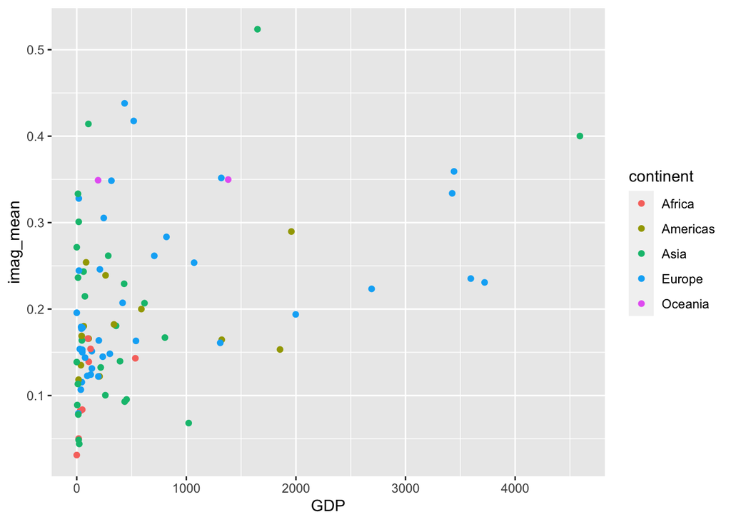

```r
# Creating a final visualization
ggplot(gdp_summary, aes(x = GDP, y = imag_mean, color = continent)) +
  geom_point()
```

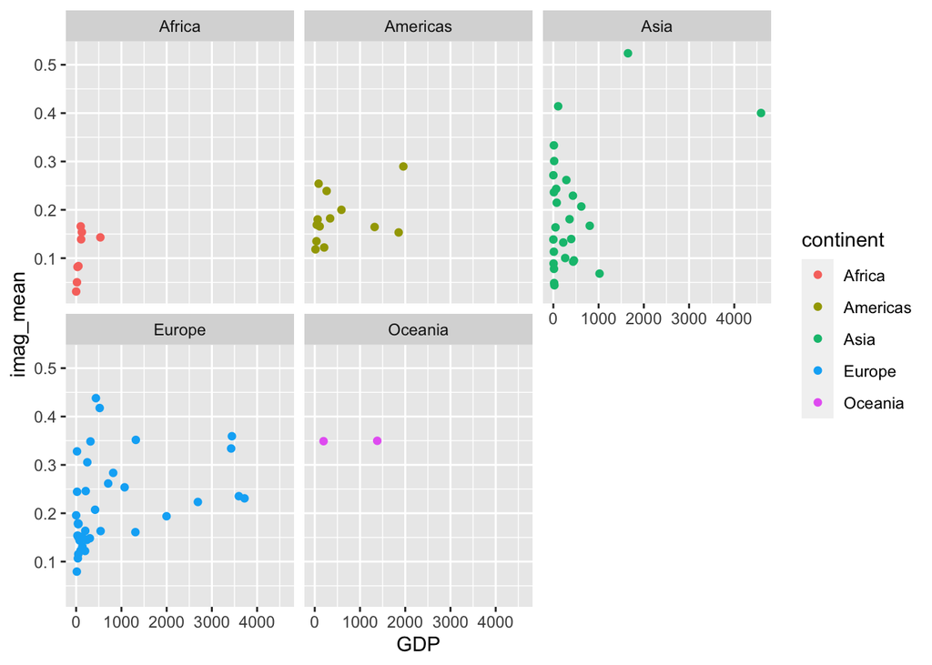

```r
ggplot(gdp_summary, aes(x = GDP, y = imag_mean, color = continent)) +
  geom_point() +
  facet_wrap(~ continent)
```

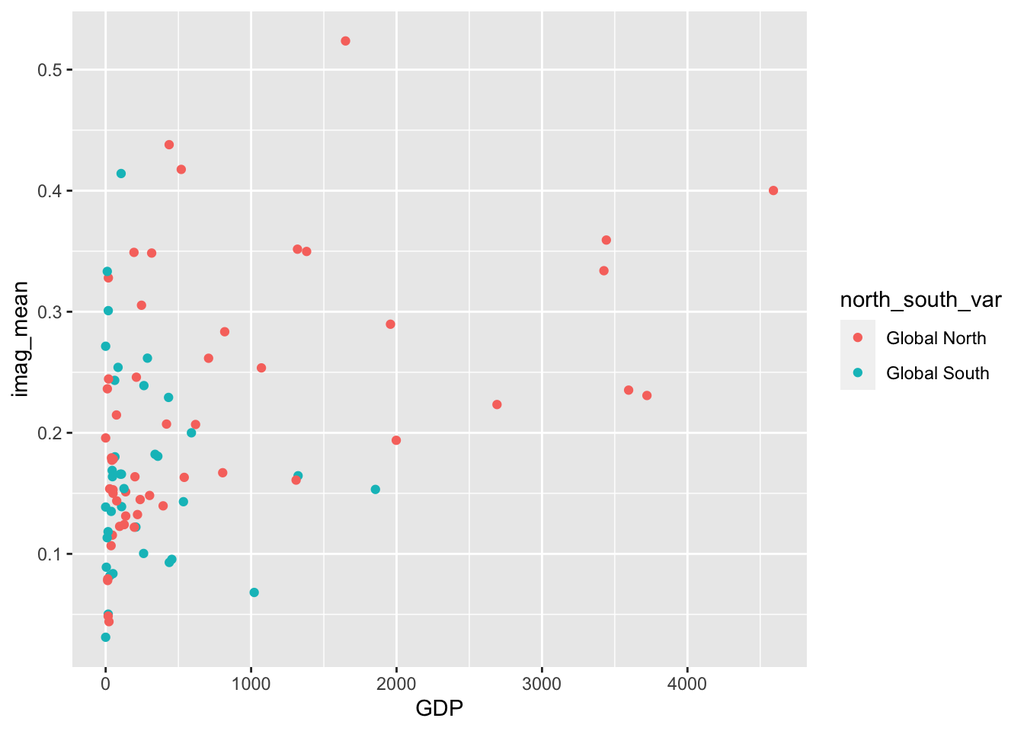

```r
ggplot(gdp_summary, aes(x = GDP, y = imag_mean, color = north_south_var)) +
  geom_point()
```

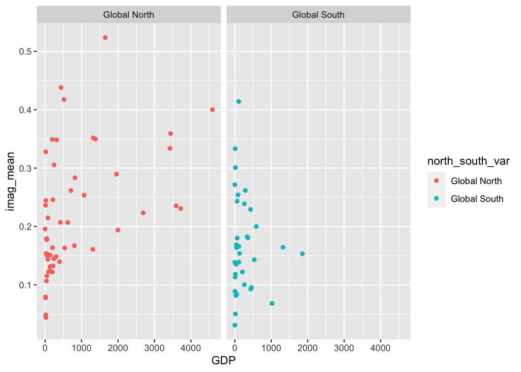

```r
ggplot(gdp_summary, aes(x = GDP, y = imag_mean, color = north_south_var)) +
  geom_point() +
  facet_wrap(~ north_south_var)
```

```r
# Calculate correlations separately
gdp_data %>%
  group_by(north_south_var) %>%
  summarize(correlation = cor(imagination, GDP, use = "complete.obs"),
            n = n())
```

```
## # A tibble: 2 × 3
##   north_south_var correlation     n
##   <chr>                 <dbl> <int>
## 1 Global North         0.0791 92713
## 2 Global South         0.0301 53439
```

The overall correlation increases by removing outliers and GDP remains a significant predictor of imagination. The plots show us substantial differences with respect to geographical regions. Not only are there regional differences with respect to means for GDP and imagination, we also see that data is more spread out for some continents.

### Gross domestic product per capita

Since we had two outliers when using the GDP for the entire country, we now use GDP per capita. Again, we want to assess socio-economic status, but we want to correct for population size, since we suspect this might remove the outliers.

```r
# GDP per capita
# Load in another GDP dataset from https://www.imf.org/external/datamapper/NGDPDPC@WEO/OEMDC/ADVEC/WEOWORLD
GDP_per_Capita <- read_excel("Downloads/imf-dm-export-20230503.xls")

# Some cleaning
GDP_per_Capita <- drop_na(GDP_per_Capita)
GDP_per_Capita[GDP_per_Capita == "no data"] <- NA
colnames(GDP_per_Capita)[1] <- "Country"

# Change country names for merging
GDP_per_Capita <- GDP_per_Capita %>%
  mutate(Country = case_when(Country == "Bosnia and Herzegovina" ~ "Bosnia & Herzegovina",
                             Country == "China, People's Republic of" ~ "China",
                             Country == "Czech Republic" ~ "Czechia",
                             Country == "Hong Kong SAR" ~ "Hong Kong SAR China",
                             Country == "Kyrgyz Republic" ~ "Kyrgyzstan",
                             Country == "Macao SAR" ~ "Macao SAR China",
                             Country == "Myanmar" ~ "Myanmar (Burma)",
                             Country == "Russian Federation" ~ "Russia",
                             Country == "Slovak Republic" ~ "Slovakia",
                             Country == "Korea, Republic of" ~ "South Korea",
                             Country == "Taiwan Province of China" ~ "Taiwan",
                             Country == "Türkiye, Republic of" ~ "Turkey",
                             TRUE ~ Country))

# Transform from wide to long format
GDP_per_Capita$Country <- factor(GDP_per_Capita$Country)
GDP_per_Capita <- gather(GDP_per_Capita, "Year", "GDP", 2:50)


# Append GDPs to Category A dataset (we have already selected valid data from Category A above)
# levels(as.factor(catA_data$year))
# levels(as.factor(GDP_per_Capita$Year))
GDP_per_Capita$Year <- as.integer(GDP_per_Capita$Year)
GDP_per_Capita$GDP <- as.numeric(GDP_per_Capita$GDP)

gdp_pc_data <- catA_data %>%
  mutate(cntry_name = case_when(cntry_name == "Northern Ireland" ~ "United Kingdom",
                                TRUE ~ cntry_name)) %>%
  left_join(GDP_per_Capita, by = c("year" = "Year", "cntry_name" = "Country"))

# levels(as.factor(gdp_pc_data[is.na(gdp_pc_data$GDP), "cntry_name"]))

# Calculate correlation
gdp_pc_data %>%
  group_by(cntry_name, year, GDP) %>%
  summarise(imag_mean = mean(imagination)) %>%
  arrange(by = desc(imag_mean))
```

```
## # A tibble: 96 × 4
## # Groups:   cntry_name, year [96]
##    cntry_name       year    GDP imag_mean
##    <chr>           <int>  <dbl>     <dbl>
##  1 South Korea      2018 33447.     0.524
##  2 Norway           2018 82843.     0.438
##  3 Sweden           2017 53459.     0.418
##  4 Myanmar (Burma)  2020  1527.     0.414
##  5 Japan            2019 40548.     0.400
##  6 United Kingdom   2022 45295.     0.359
##  7 Spain            2017 28212.     0.352
##  8 Australia        2018 56342.     0.350
##  9 New Zealand      2020 41309.     0.349
## 10 Denmark          2017 57773.     0.348
## # … with 86 more rows
```

```r
cor.test(gdp_pc_data$imagination, gdp_pc_data$GDP)
```

```
##
##  Pearson's product-moment correlation
##
## data:  gdp_pc_data$imagination and gdp_pc_data$GDP
## t = 52.569, df = 146150, p-value < 2.2e-16
## alternative hypothesis: true correlation is not equal to 0
## 95 percent confidence interval:
##  0.1311916 0.1412549
## sample estimates:
##       cor
## 0.1362268
```

```r
# Run regression
fit_GDP_pc <- glm(imagination ~ GDP, data = gdp_pc_data, family = binomial())

summary(fit_GDP_pc)
```

```
##
## Call:
## glm(formula = imagination ~ GDP, family = binomial(), data = gdp_pc_data)
##
## Deviance Residuals:
##     Min       1Q   Median       3Q      Max
## -0.9562  -0.6891  -0.6061  -0.5852   1.9287
##
## Coefficients:
##               Estimate Std. Error z value Pr(>|z|)
## (Intercept) -1.703e+00  9.956e-03 -171.01   <2e-16 ***
## GDP          1.397e-05  2.715e-07   51.44   <2e-16 ***
## ---
## Signif. codes:  0 '***' 0.001 '**' 0.01 '*' 0.05 '.' 0.1 ' ' 1
##
## (Dispersion parameter for binomial family taken to be 1)
##
##     Null deviance: 149031  on 146151  degrees of freedom
## Residual deviance: 146443  on 146150  degrees of freedom
## AIC: 146447
##
## Number of Fisher Scoring iterations: 4
```

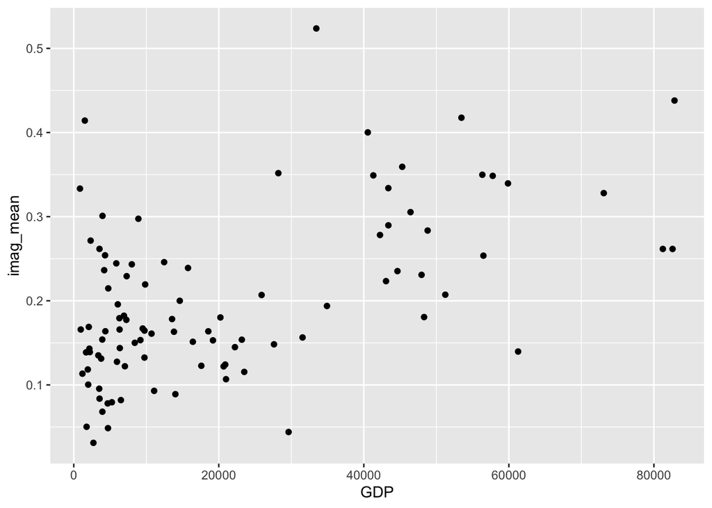

```r
# Join North South Data
gdp_pc_data <- cbind(gdp_pc_data, north_south_data$`Global North or Global South?`)
colnames(gdp_pc_data)[20] <- "north_south_var"

# Visualize these results
gdp_pc_data %>%
  group_by(cntry_name, year, GDP) %>%
  summarise(imag_mean = mean(imagination)) %>%
  ggplot(., aes(x = GDP, y = imag_mean)) +
  geom_point()
```

```r
# Calculate summary
gdp_pc_summary <- gdp_pc_data %>%
  group_by(cntry_name, year, GDP, continent, north_south_var) %>%
  summarise(imag_mean = mean(imagination)) %>%
  arrange(by = desc(GDP))
```

```
## You can override using the `.groups` argument.
```

```r
# We can see that there are no outliers (although some tax havens are over 2SD above average)
gdp_pc_summary %>%
  filter(!(GDP < mean(gdp_pc_summary$GDP, na.rm = T) + 2*sd(gdp_pc_summary$GDP, na.rm = T) &
           GDP > mean(gdp_pc_summary$GDP, na.rm = T) - 2*sd(gdp_pc_summary$GDP, na.rm = T)))
```

```
## # A tibble: 4 × 6
## # Groups:   cntry_name, year, GDP, continent [4]
##   cntry_name       year    GDP continent north_south_var imag_mean
##   <chr>           <int>  <dbl> <chr>     <chr>               <dbl>
## 1 Norway           2018 82843. Europe    Global North        0.438
## 2 Switzerland      2017 82572. Europe    Global North        0.262
## 3 Macao SAR China  2019 81232. Asia      Global South        0.262
## 4 Iceland          2017 73085. Europe    Global North        0.328
```

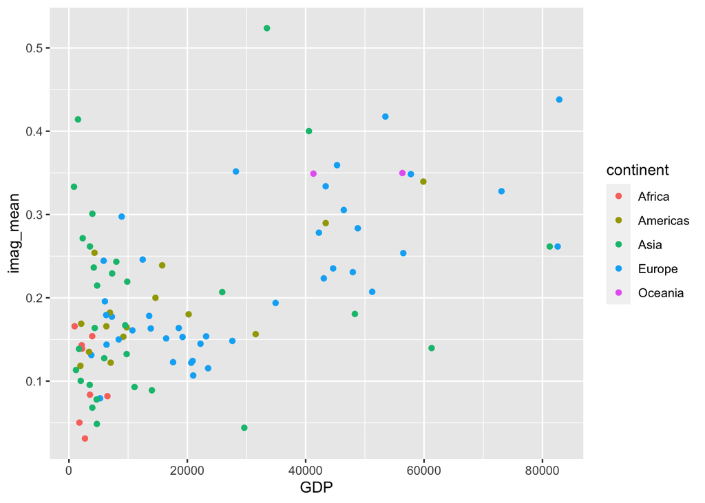

```r
# Creating a final visualization
ggplot(gdp_pc_summary, aes(x = GDP, y = imag_mean, color = continent)) +
  geom_point()
```

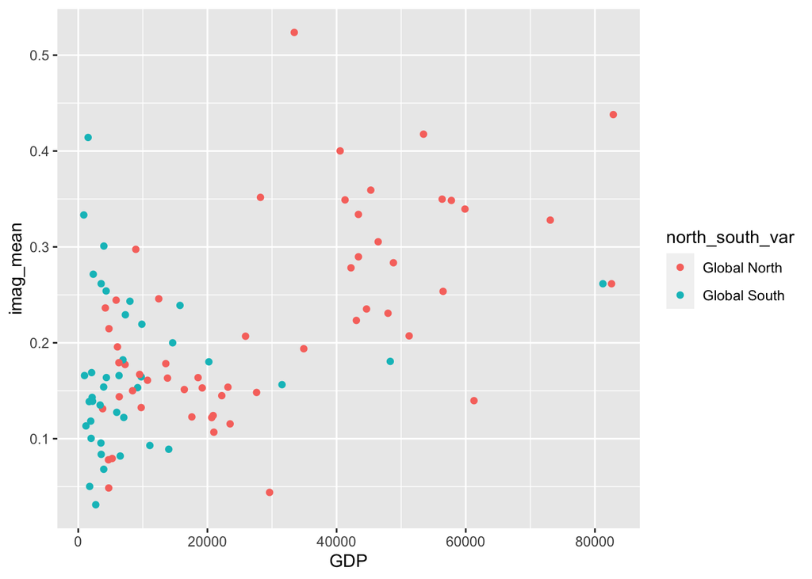

```r
ggplot(gdp_pc_summary, aes(x = GDP, y = imag_mean, color = north_south_var)) +
  geom_point()
```

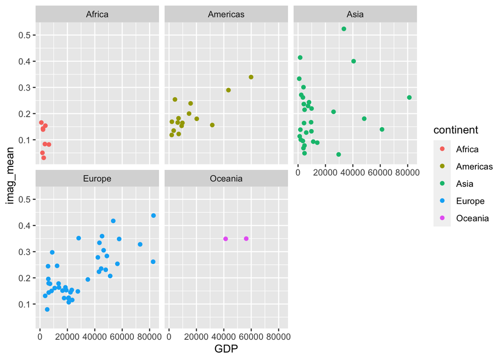

```r
ggplot(gdp_pc_summary, aes(x = GDP, y = imag_mean, color = continent)) +
  geom_point() +
  facet_wrap(~ continent)
```

We found slightly higher correlations and no outliers when using GDP per capita. GDP remains a significant predictor of imagination, which indicates that socio-economic status of a country is a (weak) correlate of valuing imagination.

# Summary

In this analysis, we aimed to answer the following questions:

- How important is imagination compared to other qualities/values across countries?
- What are the correlates of valuing imagination?

using the EVS/WVS joint data set. We specifically looked at the items on child qualities, where participants were asked to choose up to five out of eleven qualities they deemed important for a child to have.

Overall, imagination was included by between 3.11% and 52.37% of participants for a given country. We also assessed the relative importance of imagination by calculating how imagination ranked among all qualities. We found substantial differences, with imagination being considered the 5th to 11th most important quality between countries.

We created map visualizations for these results, which offered the following insights: Countries of the global North appeared to rate imagination more highly than countries of the global South. The country where most people included imagination in their Top 5 qualities was South Korea with 52.4%. Notably, most (culturally) Scandinavian countries also rated very highly (30.53% - 43.80%).

On the other hand, the countries that included imagination the least were mostly countries of the Global South, with Egypt ranking the lowest. Only 3.11% of the Egyptian sample included imagination in their quality list.

We then tested self-reported income decile (compared to average income of a country) as a predictor of imagination. Income decile significantly predicted imagination, with higher levels of income being associated with being more likely to value imagination.

Second, we tested external data as predictors of imagination. We used a dataset on geographical location to see whether countries of the Global North were indeed more likely to value imagination. We found individuals from countries of the global North to score significantly higher compared to those from countries of the Global South.

We then looked at GDP by country as a predictor. In a logistic regression, GDP significantly predicted whether imagination was included or not. Participants from a country with a higher GDP were more likely to include imagination in the qualities they considered most important for children.

We also checked GDP per capita to correct for population size. Correlations were slightly higher, although still very weak (r = 0.14) and GDP per capita also significantly predicted imagination.

## Limitations

The data does not allow to assess the absolute importance of imagination. As we already described when looking at correlations, any quality will correlate negatively with the other ones because participants are not asked which qualities they consider important but are limited to the five which they consider most important. This prevents us from drawing conclusions such as ‘People from country A think imagination is not very important’ because we can only say so relative to other traits. This also offers an explanation to why GDP and income decile predict imagination - perhaps economic insecurity relates to people valuing other qualities in children over imagination.